# Feed Status Effect on Microbiome at 15 Days

Edgardo L. Rosado Ramos

2025-11-21

# Analysis Overview

**Research Question:** Does feeding status (Fed vs. Unfed) affect the gut microbiome composition in 15-day-old snakes? **Hypothesis:** Fed snakes will have different microbiome composition due to nutrient influx and altered gut environment. # Setup

```r
library(phyloseq)
library(vegan)
library(tidyverse)
library(ggplot2)
library(patchwork)
library(ggpubr)
library(kableExtra)
library(DESeq2)
theme_set(theme_bw(base_size = 14))
```

# Data Loading

```r
# Load OTU Table
otu_raw <- read.table("kohler.opti_mcc.0.03.subsample.shared", header = TRUE, sep = "\t")
otu_mat <- otu_raw[, -(1:3)]
rownames(otu_mat) <- otu_raw$Group
otu_mat <- t(otu_mat)
otu_tab <- otu_table(otu_mat, taxa_are_rows = TRUE)
# Load Taxonomy
tax_raw <- read.table("kohler.opti_mcc.0.03.cons.taxonomy",
                      sep = "\t", header = TRUE, stringsAsFactors = FALSE, quote = "")
taxonomy_strings <- tax_raw$Taxonomy
names(taxonomy_strings) <- tax_raw$OTU
taxonomy_clean <- lapply(strsplit(taxonomy_strings, ";"), function(x) {
  x <- x[nchar(x) > 0]
  x <- gsub("\\(.*?\\)|\\\"", "", x)
  trimws(x)
})
max_ranks <- 7
taxonomy_mat <- do.call(rbind, lapply(taxonomy_clean, `length<-`, max_ranks))
colnames(taxonomy_mat) <- c("Kingdom", "Phylum", "Class", "Order", "Family", "Genus", "Species")
rownames(taxonomy_mat) <- names(taxonomy_strings)
tax_tab <- tax_table(as.matrix(taxonomy_mat))
# Load Metadata
Kohler.design <- read.table("Kohlerdesign.txt",
                            header = TRUE, sep = "\t", row.names = 1,
                            stringsAsFactors = TRUE, check.names = FALSE)
# Create Phyloseq
common_samples <- intersect(sample_names(otu_tab), rownames(Kohler.design))
otu_tab_pruned <- prune_samples(common_samples, otu_tab)
sample_data_obj <- sample_data(Kohler.design[common_samples, ])
physeq <- phyloseq(otu_tab_pruned, tax_tab, sample_data_obj)
# Rarefy
physeq_filt <- filter_taxa(physeq, function(x) sum(x > 3) > (0.2 * length(x)), TRUE)
min_depth <- min(sample_sums(physeq_filt))
set.seed(42)
physeq_rarefied <- rarefy_even_depth(physeq_filt, sample.size = min_depth, replace = FALSE)
# Alpha Diversity
alpha_diversity_rarefied <- estimate_richness(physeq_rarefied, measures = c("Observed", "Shannon", "Chao1"))
sample_metadata_rarefied <- as.data.frame(sample_data(physeq_rarefied))
alpha_data_rarefied <- cbind(alpha_diversity_rarefied, sample_metadata_rarefied)
```

# Subset to 15-Day Samples

```r
physeq_15days <- subset_samples(physeq_rarefied, Age == "15+days")
alpha_15days <- alpha_data_rarefied %>% filter(Age == "15+days")
cat("Total 15-day samples:", nsamples(physeq_15days), "\n")
```

```
## Total 15-day samples: 11
```

```r
cat("Sample breakdown:\n")
```

```
## Sample breakdown:
```

```r
table(sample_data(physeq_15days)$Feed, sample_data(physeq_15days)$SampleType)
```

```
##
##       Muck Sterile
##   No     2       4
##   Yes    1       4
```

# Sample Distribution

```r
sample_summary <- alpha_15days %>%
  group_by(SampleType, Feed) %>%
  summarise(n = n(), .groups = "drop")
knitr::kable(sample_summary,
             caption = "Sample Distribution at 15 Days",
             col.names = c("Treatment", "Feed Status", "Sample Size")) %>%
  kable_styling(bootstrap_options = c("striped", "hover"), full_width = FALSE)
```

Sample Distribution at 15 Days

| Treatment | Feed Status | Sample Size |
| --- | --- | --- |
| Muck | No | 2 |
| Muck | Yes | 1 |
| Sterile | No | 4 |
| Sterile | Yes | 4 |

# Alpha Diversity Analysis

## Shannon Diversity

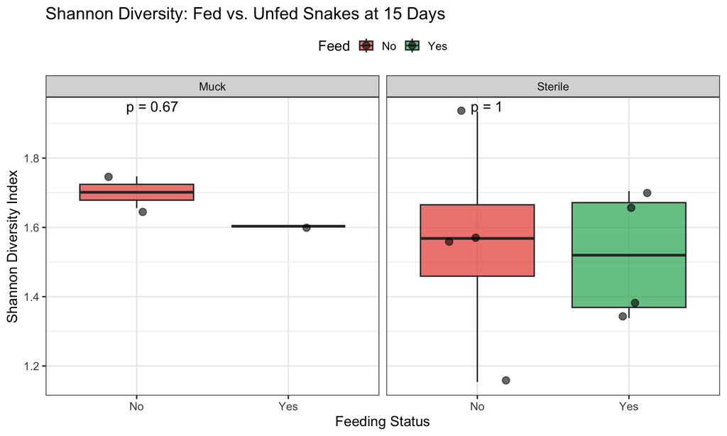

```r
p_shannon <- ggplot(alpha_15days, aes(x = Feed, y = Shannon, fill = Feed)) +
  geom_boxplot(alpha = 0.7, outlier.shape = NA) +
  geom_jitter(width = 0.2, size = 3, alpha = 0.6) +
  facet_wrap(~ SampleType) +
  scale_fill_manual(values = c("No" = "#e74c3c", "Yes" = "#27ae60")) +
  stat_compare_means(method = "wilcox.test", label = "p.format", size = 5) +
  labs(title = "Shannon Diversity: Fed vs. Unfed Snakes at 15 Days",
       y = "Shannon Diversity Index",
       x = "Feeding Status") +
  theme(legend.position = "top", text = element_text(size = 14))
print(p_shannon)
```

```r
ggsave("FeedStatus_Shannon.pdf", p_shannon, width = 10, height = 6)
```

## Observed OTUs

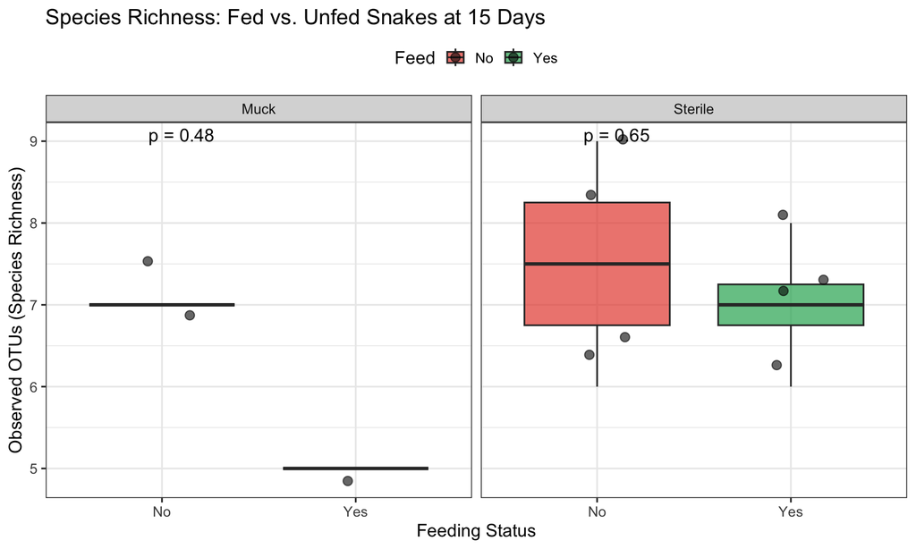

```r
p_observed <- ggplot(alpha_15days, aes(x = Feed, y = Observed, fill = Feed)) +
  geom_boxplot(alpha = 0.7, outlier.shape = NA) +
  geom_jitter(width = 0.2, size = 3, alpha = 0.6) +
  facet_wrap(~ SampleType) +
  scale_fill_manual(values = c("No" = "#e74c3c", "Yes" = "#27ae60")) +
  stat_compare_means(method = "wilcox.test", label = "p.format", size = 5) +
  labs(title = "Species Richness: Fed vs. Unfed Snakes at 15 Days",
       y = "Observed OTUs (Species Richness)",
       x = "Feeding Status") +
  theme(legend.position = "top", text = element_text(size = 14))
print(p_observed)
```

```r
ggsave("FeedStatus_Richness.pdf", p_observed, width = 10, height = 6)
```

## Summary Statistics

```r
alpha_stats <- alpha_15days %>%
  group_by(SampleType, Feed) %>%
  summarise(
    n = n(),
    Shannon_mean = mean(Shannon, na.rm = TRUE),
    Shannon_sd = sd(Shannon, na.rm = TRUE),
    Observed_mean = mean(Observed, na.rm = TRUE),
    Observed_sd = sd(Observed, na.rm = TRUE),
    .groups = "drop"
  ) %>%
  mutate(
    Shannon = paste0(round(Shannon_mean, 2), " ± ", round(Shannon_sd, 2)),
    Richness = paste0(round(Observed_mean, 1), " ± ", round(Observed_sd, 1))
  ) %>%
  dplyr::select(SampleType, Feed, n, Shannon, Richness)
knitr::kable(alpha_stats,
             col.names = c("Treatment", "Fed?", "n", "Shannon (Mean ± SD)", "Richness (Mean ± SD)"),
             caption = "Alpha Diversity Summary Statistics") %>%
  kable_styling(bootstrap_options = c("striped", "hover"), full_width = FALSE)
```

Alpha Diversity Summary Statistics

| Treatment | Fed? | n | Shannon (Mean ± SD) | Richness (Mean ± SD) |
| --- | --- | --- | --- | --- |
| Muck | No | 2 | 1.7 ± 0.06 | 7 ± 0 |
| Muck | Yes | 1 | 1.6 ± NA | 5 ± NA |
| Sterile | No | 4 | 1.56 ± 0.32 | 7.5 ± 1.3 |
| Sterile | Yes | 4 | 1.52 ± 0.19 | 7 ± 0.8 |

```r
write.csv(alpha_stats, "FeedStatus_AlphaStats.csv", row.names = FALSE)
```

# Beta Diversity Analysis

## PERMANOVA: Feed Status Effect

```r
# Calculate Bray-Curtis distance
bray_15days <- phyloseq::distance(physeq_15days, method = "bray")
metadata_15days <- data.frame(sample_data(physeq_15days))
# PERMANOVA testing Feed + SampleType + Mother
set.seed(42)
permanova_feed <- adonis2(
  bray_15days ~ Feed + SampleType + Mother,
  data = metadata_15days,
  permutations = 9999,
  by = "margin"
)
print(permanova_feed)
```

```
## Permutation test for adonis under reduced model
## Marginal effects of terms
## Permutation: free
## Number of permutations: 9999
##
## adonis2(formula = bray_15days ~ Feed + SampleType + Mother, data = metadata_15days, permutations = 9999, by = "margin")
##            Df SumOfSqs      R2      F Pr(>F)
## Feed        0  0.00000 0.00000    NaN
## SampleType  1  0.06197 0.03023 0.5902 0.6491
## Mother      1  0.39001 0.19027 3.7146 0.0471 *
## Residual    7  0.73496 0.35857
## Total      10  2.04974 1.00000
## ---
## Signif. codes:  0 '***' 0.001 '**' 0.01 '*' 0.05 '.' 0.1 ' ' 1
```

```r
# Create effect size table
effect_table_feed <- data.frame(
  Factor = c("Feed Status", "Treatment (Muck/Sterile)", "Maternal ID"),
  R2 = c(
    permanova_feed$R2[which(rownames(permanova_feed) == "Feed")],
    permanova_feed$R2[which(rownames(permanova_feed) == "SampleType")],
    permanova_feed$R2[which(rownames(permanova_feed) == "Mother")]
  ),
  F_stat = c(
    permanova_feed$F[which(rownames(permanova_feed) == "Feed")],
    permanova_feed$F[which(rownames(permanova_feed) == "SampleType")],
    permanova_feed$F[which(rownames(permanova_feed) == "Mother")]
  ),
  p_value = c(
    permanova_feed$`Pr(>F)`[which(rownames(permanova_feed) == "Feed")],
    permanova_feed$`Pr(>F)`[which(rownames(permanova_feed) == "SampleType")],
    permanova_feed$`Pr(>F)`[which(rownames(permanova_feed) == "Mother")]
  )
) %>%
  mutate(
    `R² (%)` = round(R2 * 100, 1),
    `F-statistic` = round(F_stat, 2),
    `p-value` = format.pval(p_value, digits = 3),
    Significance = case_when(
      p_value < 0.001 ~ "***",
      p_value < 0.01 ~ "**",
      p_value < 0.05 ~ "*",
      TRUE ~ "ns"
    )
  ) %>%
  dplyr::select(Factor, `R² (%)`, `F-statistic`, `p-value`, Significance)
knitr::kable(effect_table_feed,
             caption = "PERMANOVA: Drivers of Microbiome Variation at 15 Days",
             align = "lcccc") %>%
  kable_styling(bootstrap_options = c("striped", "hover"), full_width = FALSE) %>%
  row_spec(1, bold = TRUE, background = "#fff3cd")  # Highlight Feed Status
```

PERMANOVA: Drivers of Microbiome Variation at 15 Days

Factor

R² (%)

F-statistic

p-value

Significance

Feed Status

0

NaN

NA

ns

Treatment (Muck/Sterile)

3

0.59

0.6491

ns

Maternal ID

19

3.71

0.0471

```r
write.csv(effect_table_feed, "FeedStatus_PERMANOVA.csv", row.names = FALSE)
```

## PCoA Ordination

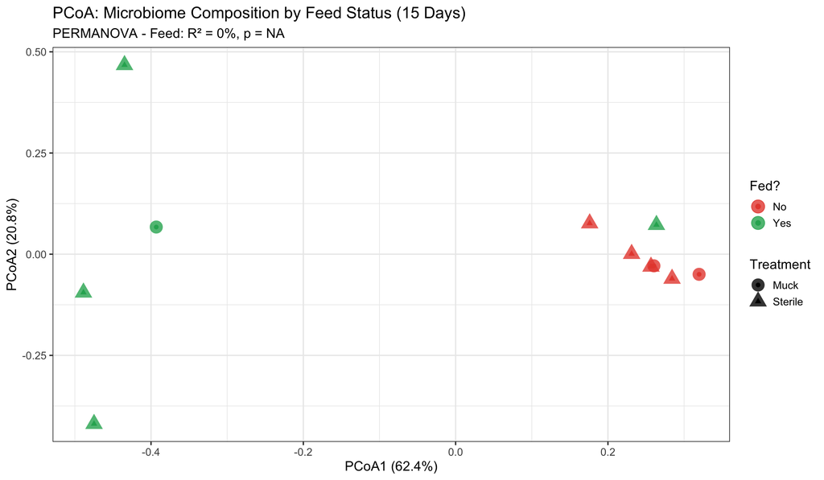

```r
pcoa_15days <- ordinate(physeq_15days, method = "PCoA", distance = bray_15days)
p_pcoa <- plot_ordination(physeq_15days, pcoa_15days,
                          color = "Feed", shape = "SampleType") +
  geom_point(size = 6, alpha = 0.8) +
  scale_color_manual(values = c("No" = "#e74c3c", "Yes" = "#27ae60"),
                     name = "Fed?") +
  scale_shape_manual(values = c(16, 17), name = "Treatment") +
  labs(
    title = "PCoA: Microbiome Composition by Feed Status (15 Days)",
    subtitle = paste0("PERMANOVA - Feed: R² = ",
                     round(effect_table_feed$`R² (%)`, 1)[1],
                     "%, p = ", effect_table_feed$`p-value`[1]),
    x = paste0("PCoA1 (", round(pcoa_15days$values$Relative_eig[1] * 100, 1), "%)"),
    y = paste0("PCoA2 (", round(pcoa_15days$values$Relative_eig[2] * 100, 1), "%)")
  ) +
  theme(legend.position = "right", text = element_text(size = 14))
print(p_pcoa)
```

```r
ggsave("FeedStatus_PCoA.pdf", p_pcoa, width = 12, height = 7)
```